# Final Project 2: Heart Disease Analysis

Lauren McGarvey

2026-11-05

# Introduction

## The Data

The data used in this project come from the Heart Disease dataset available through the UCI Machine Learning Repository. The dataset contains information on 303 patients, including demographic and health-related characteristics such as age, sex, chest pain type, resting blood pressure, cholesterol, maximum heart rate, and heart disease status. The goal of this analysis is to describe the characteristics of patients in the dataset and examine how selected health characteristics differ between patients with and without heart disease. I use descriptive statistics and visualizations to explore the data.

## Objectives

1. Load and inspect the Heart Disease dataset.
2. Describe the characteristics of patients with and without heart disease.
3. Compare selected health characteristics between the two groups.
4. Visualize differences in age by heart disease status.

# Table 1: Patient Characteristics by Heart Disease Status

Patient Characteristics by Heart Disease Status

| Heart Disease Status | N | Mean Age | Mean Cholesterol | Mean Blood Pressure | Mean Maximum Heart Rate |
| --- | --- | --- | --- | --- | --- |
| Heart disease | 139 | 56.6 | 251.5 | 134.6 | 139.3 |
| No heart disease | 164 | 52.6 | 242.6 | 129.2 | 158.4 |

Table 1 summarizes the characteristics of patients with and without heart disease: the number of patients in each group and the mean age, cholesterol level, resting blood pressure, and maximum heart rate.

# Figure 1: Age by Heart Disease Status

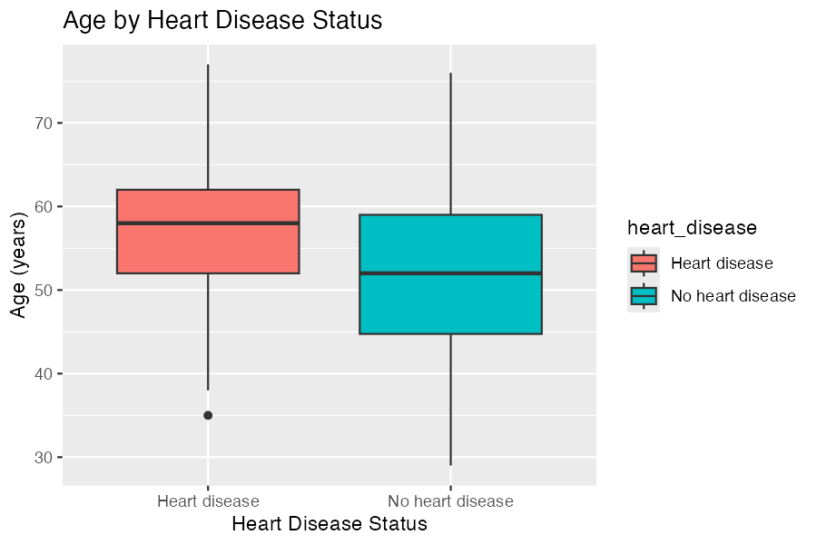

Figure 1 compares the distribution of age between patients with and without heart disease. The boxplots show the median and spread of age within each group.

# Next Steps

For the final report, I plan to explore additional characteristics of the dataset, create additional visualizations, and possibly conduct statistical analyses to examine which characteristics are associated with the presence of heart disease.